# CSML1000 Winter 2020, Group 8, Assignment1: Breast Cancer Diagnosis Prediction Model

Steven Wang, Tarun Bagga, Paul Doucet, Jerry Khidaroo,

2/15/2020

## Load Libraries

```r
# Load packages
library('ggplot2') # visualization
library('ggthemes') # visualization
library('scales') # visualization
library('dplyr') # data manipulation
library('mice') # imputation
library('randomForest') # classification algorithm
library('caret')
library('e1071')
library('shiny')
library('shinythemes')
library('readr')
# load the package "nnet" which provide the ANN modeling functionality
library("nnet")
# load the libary "purrr" for the ANN function map
library("purrr")
library('corrplot')
library('data.table')
library('caTools')
# library(klaR)
```

## 1. Business Understanding

- Business Problem: When a patient has a Radiologic Study done to image a tumor there can be a lengthy wait time between the capture of the study and recording of the measurement by the technologist to the time when the tumor is identified as ‘Benign’ or ‘Maligant’ either through a Radiologist Observation Result or a Biopsy Result. A machine Learning Model that could predict the diagnosis as soon as the measurements are entered would give Clinicians an early warning tool that could speed up the time for the start of treatment of a patient.
- Project Plan:
  - Load and get an understanding of the dataset, its target variable and its features.
  - Make any modifications to the dataset needed to enable learning algorithms to be run on the data.
  - Identify the features of the dataset that are important in predicting the target variable (dianosis in this case).
  - Build and evaluate 3 to 4 Models from the dataset by appling various machine learning algoritms as appropiate and testing them.
  - Identify the best model to use for the project.
  - Build a shiny app that deploys the selected model with a user interface for end users to imput measurement values from a study and obtain a pridiction result.
  - Identify any ethical considerations that should be addressed at each stage of the process.
- Business Success Criteria: A successful project outcome would be achieved if a model is created that can predict the ‘B’ or ‘M’ outcome with a high degree of accuracy and sensitivity when given an unlabeled set of measurements from a tumor study.
- Ethical Framework Questions:
  - How could your system negatively impact individuals? The greatest negative impact would occur for a false positive diagnosis since this could delay treatment and in a life threatening scenario. A false negative would also be negatively impactful but to a lessor degree.
  - Who is most vulnerable and why? The most vulnerable would be patients with a ‘M’ dianosis not detectable by the model.
  - How much error in predictions can your business accept for this use case? False positives need to be minimised as much as posible. Minimsing False negatives are second in priority.
  - Will you need to explain which input factors had the greatest influence on outputs? Yes. Being able to explain which features have the most influence on outcome is very desirable.
  - Do you need PII or can you provide group-level data? The analysis requires patient level data however any PII can be anonymised

## 2. Data Understanding

- Ethical Framework Questions:
  - Have you de-identified your data and taken measures to reduce the probability of reidentification? The data is de-identified.
  - Will socially sensitive features like gender or ethnic background influence outputs? No demographic data is present.
  - Are seemingly harmless features like location hiding proxies for socially sensitive features? No demographic data is present.

#### Get Data File

- The Dataset used is obtained from: https://www.kaggle.com/uciml/breast-cancer-wisconsin-data

```r
# Concatenate data file subdir and name.
full_file_name <- paste("./input/diagnosis_data.csv",sep="")
show(full_file_name)
```

```
## [1] "./input/diagnosis_data.csv"
```

#### Load and check data

```r
# Load full data
diagnosis_data_full = read.csv(full_file_name)
breastcancer_data <- read.csv(full_file_name)

# check data
str(diagnosis_data_full)
```

```
## 'data.frame':    569 obs. of  33 variables:
##  $ id                     : int  842302 842517 84300903 84348301 84358402 843786 844359 84458202 844981 84501001 ...
##  $ diagnosis              : Factor w/ 2 levels "B","M": 2 2 2 2 2 2 2 2 2 2 ...
##  $ radius_mean            : num  18 20.6 19.7 11.4 20.3 ...
##  $ texture_mean           : num  10.4 17.8 21.2 20.4 14.3 ...
##  $ perimeter_mean         : num  122.8 132.9 130 77.6 135.1 ...
##  $ area_mean              : num  1001 1326 1203 386 1297 ...
##  $ smoothness_mean        : num  0.1184 0.0847 0.1096 0.1425 0.1003 ...
##  $ compactness_mean       : num  0.2776 0.0786 0.1599 0.2839 0.1328 ...
##  $ concavity_mean         : num  0.3001 0.0869 0.1974 0.2414 0.198 ...
##  $ concave.points_mean    : num  0.1471 0.0702 0.1279 0.1052 0.1043 ...
##  $ symmetry_mean          : num  0.242 0.181 0.207 0.26 0.181 ...
##  $ fractal_dimension_mean : num  0.0787 0.0567 0.06 0.0974 0.0588 ...
##  $ radius_se              : num  1.095 0.543 0.746 0.496 0.757 ...
##  $ texture_se             : num  0.905 0.734 0.787 1.156 0.781 ...
```

[output cut: 19 more lines]

```r
summary(diagnosis_data_full)
```

```
##        id            diagnosis  radius_mean      texture_mean
##  Min.   :     8670   B:357     Min.   : 6.981   Min.   : 9.71
##  1st Qu.:   869218   M:212     1st Qu.:11.700   1st Qu.:16.17
##  Median :   906024             Median :13.370   Median :18.84
##  Mean   : 30371831             Mean   :14.127   Mean   :19.29
##  3rd Qu.:  8813129             3rd Qu.:15.780   3rd Qu.:21.80
##  Max.   :911320502             Max.   :28.110   Max.   :39.28
##  perimeter_mean     area_mean      smoothness_mean   compactness_mean
##  Min.   : 43.79   Min.   : 143.5   Min.   :0.05263   Min.   :0.01938
##  1st Qu.: 75.17   1st Qu.: 420.3   1st Qu.:0.08637   1st Qu.:0.06492
##  Median : 86.24   Median : 551.1   Median :0.09587   Median :0.09263
##  Mean   : 91.97   Mean   : 654.9   Mean   :0.09636   Mean   :0.10434
##  3rd Qu.:104.10   3rd Qu.: 782.7   3rd Qu.:0.10530   3rd Qu.:0.13040
##  Max.   :188.50   Max.   :2501.0   Max.   :0.16340   Max.   :0.34540
##  concavity_mean    concave.points_mean symmetry_mean    fractal_dimension_mean
##  Min.   :0.00000   Min.   :0.00000     Min.   :0.1060   Min.   :0.04996
##  1st Qu.:0.02956   1st Qu.:0.02031     1st Qu.:0.1619   1st Qu.:0.05770
##  Median :0.06154   Median :0.03350     Median :0.1792   Median :0.06154
##  Mean   :0.08880   Mean   :0.04892     Mean   :0.1812   Mean   :0.06280
##  3rd Qu.:0.13070   3rd Qu.:0.07400     3rd Qu.:0.1957   3rd Qu.:0.06612
##  Max.   :0.42680   Max.   :0.20120     Max.   :0.3040   Max.   :0.09744
##    radius_se        texture_se      perimeter_se       area_se
##  Min.   :0.1115   Min.   :0.3602   Min.   : 0.757   Min.   :  6.802
##  1st Qu.:0.2324   1st Qu.:0.8339   1st Qu.: 1.606   1st Qu.: 17.850
##  Median :0.3242   Median :1.1080   Median : 2.287   Median : 24.530
##  Mean   :0.4052   Mean   :1.2169   Mean   : 2.866   Mean   : 40.337
##  3rd Qu.:0.4789   3rd Qu.:1.4740   3rd Qu.: 3.357   3rd Qu.: 45.190
##  Max.   :2.8730   Max.   :4.8850   Max.   :21.980   Max.   :542.200
##  smoothness_se      compactness_se      concavity_se     concave.points_se
##  Min.   :0.001713   Min.   :0.002252   Min.   :0.00000   Min.   :0.000000
##  1st Qu.:0.005169   1st Qu.:0.013080   1st Qu.:0.01509   1st Qu.:0.007638
##  Median :0.006380   Median :0.020450   Median :0.02589   Median :0.010930
##  Mean   :0.007041   Mean   :0.025478   Mean   :0.03189   Mean   :0.011796
##  3rd Qu.:0.008146   3rd Qu.:0.032450   3rd Qu.:0.04205   3rd Qu.:0.014710
##  Max.   :0.031130   Max.   :0.135400   Max.   :0.39600   Max.   :0.052790
##   symmetry_se       fractal_dimension_se  radius_worst   texture_worst
##  Min.   :0.007882   Min.   :0.0008948    Min.   : 7.93   Min.   :12.02
##  1st Qu.:0.015160   1st Qu.:0.0022480    1st Qu.:13.01   1st Qu.:21.08
##  Median :0.018730   Median :0.0031870    Median :14.97   Median :25.41
##  Mean   :0.020542   Mean   :0.0037949    Mean   :16.27   Mean   :25.68
```

[output cut: 8 more lines]

```
##  Max.   :251.20   Max.   :4254.0   Max.   :0.22260   Max.   :1.05800
##  concavity_worst  concave.points_worst symmetry_worst   fractal_dimension_worst
##  Min.   :0.0000   Min.   :0.00000      Min.   :0.1565   Min.   :0.05504
##  1st Qu.:0.1145   1st Qu.:0.06493      1st Qu.:0.2504   1st Qu.:0.07146
##  Median :0.2267   Median :0.09993      Median :0.2822   Median :0.08004
##  Mean   :0.2722   Mean   :0.11461      Mean   :0.2901   Mean   :0.08395
##  3rd Qu.:0.3829   3rd Qu.:0.16140      3rd Qu.:0.3179   3rd Qu.:0.09208
##  Max.   :1.2520   Max.   :0.29100      Max.   :0.6638   Max.   :0.20750
##     X
##  Mode:logical
##  NA's:569
##
##
##
##
```

```r
# head(diagnosis_data_full)
```

- From an intial examination of the dataset we have a target variable: diagnosis, with values of ‘B’ for benign and ‘M’ for malignant. There are no missing entries in the dataset,
- The last column, ‘X’ has no information and the ‘ID’ column is not useful for analysis.

## 3. Data Preparation

#### Column Removals

```r
# Remove Lines for the ID and Null X final Columns
diagnosis_data_full <- diagnosis_data_full[2:32]
```

#### Scale Data Set

```r
# Encoding the target feature as factor
# diagnosis_data_full$diagnosis = factor(diagnosis_data_full$diagnosis,
#                                        levels = c('B', 'M'),
#                                        labels = c(0,1))

# Scaling the dataset for models that require it
diagnosis_data_scaled <- diagnosis_data_full
diagnosis_data_scaled[,2:31] <- scale(diagnosis_data_scaled[,2:31])
str(diagnosis_data_scaled)
```

```
## 'data.frame':    569 obs. of  31 variables:
##  $ diagnosis              : Factor w/ 2 levels "B","M": 2 2 2 2 2 2 2 2 2 2 ...
##  $ radius_mean            : num  1.096 1.828 1.578 -0.768 1.749 ...
##  $ texture_mean           : num  -2.072 -0.353 0.456 0.254 -1.151 ...
##  $ perimeter_mean         : num  1.269 1.684 1.565 -0.592 1.775 ...
##  $ area_mean              : num  0.984 1.907 1.558 -0.764 1.825 ...
##  $ smoothness_mean        : num  1.567 -0.826 0.941 3.281 0.28 ...
##  $ compactness_mean       : num  3.281 -0.487 1.052 3.4 0.539 ...
##  $ concavity_mean         : num  2.6505 -0.0238 1.3623 1.9142 1.3698 ...
##  $ concave.points_mean    : num  2.53 0.548 2.035 1.45 1.427 ...
##  $ symmetry_mean          : num  2.21557 0.00139 0.93886 2.86486 -0.00955 ...
##  $ fractal_dimension_mean : num  2.254 -0.868 -0.398 4.907 -0.562 ...
##  $ radius_se              : num  2.488 0.499 1.228 0.326 1.269 ...
##  $ texture_se             : num  -0.565 -0.875 -0.779 -0.11 -0.79 ...
##  $ perimeter_se           : num  2.831 0.263 0.85 0.286 1.272 ...
```

[output cut: 17 more lines]

```r
names(diagnosis_data_full)
```

```
##  [1] "diagnosis"               "radius_mean"
##  [3] "texture_mean"            "perimeter_mean"
##  [5] "area_mean"               "smoothness_mean"
##  [7] "compactness_mean"        "concavity_mean"
##  [9] "concave.points_mean"     "symmetry_mean"
## [11] "fractal_dimension_mean"  "radius_se"
## [13] "texture_se"              "perimeter_se"
## [15] "area_se"                 "smoothness_se"
## [17] "compactness_se"          "concavity_se"
## [19] "concave.points_se"       "symmetry_se"
## [21] "fractal_dimension_se"    "radius_worst"
## [23] "texture_worst"           "perimeter_worst"
## [25] "area_worst"              "smoothness_worst"
## [27] "compactness_worst"       "concavity_worst"
## [29] "concave.points_worst"    "symmetry_worst"
## [31] "fractal_dimension_worst"
```

#### Split Data into Train and Test Sets

- Here we are splitting the datatsets in test and train datasets which alows for running the models.

```r
# Split the data into a train set and a test set
diagnosis_data_train <- diagnosis_data_full[1:426,]
diagnosis_data_test <- diagnosis_data_full[427:569,]
# Split the scaled version as well
diag_data_scaled_train <- diagnosis_data_scaled[1:426,]
diag_data_scaled_test <- diagnosis_data_scaled[427:569,]
```

#### The Dependent Variable

- The dependant variable in our analysis ‘Diagnosis’ of cancer was of interest during data exploration. It has slight imbalance data and binary classification of benign and malignant. We can check it by looking at the breakdown on the dependent variable.

```r
prop.table(table(diagnosis_data_train$diagnosis))*100
```

```
##
##       B       M
## 58.4507 41.5493
```

```r
prop.table(table(diagnosis_data_test$diagnosis))*100
```

```
##
##        B        M
## 75.52448 24.47552
```

#### View Correlation Matrix to explore highly correlated features

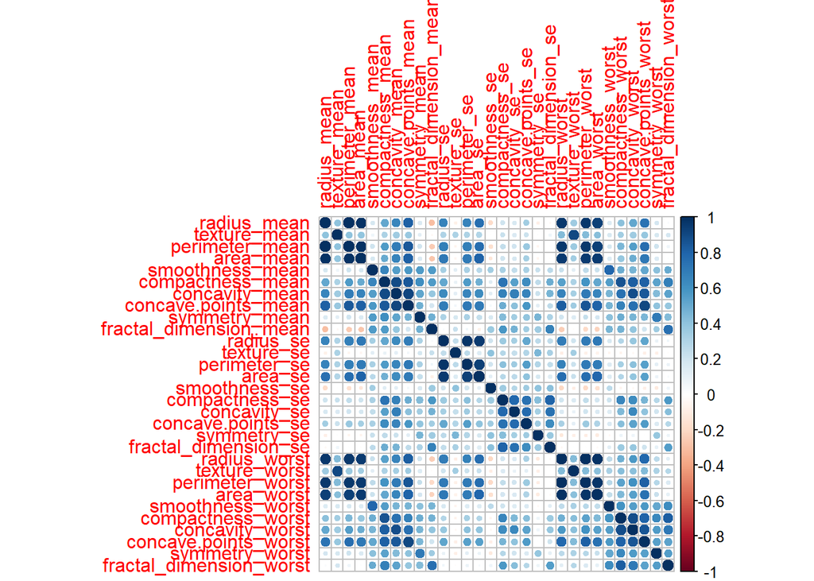

```r
M <- cor(diagnosis_data_train[,2:31])
# 24) perimeter_worst, 19) concave.points_worst, 22) radius_worst, 9) concave.points_mean, 8) concavity_mean
# M <- cor(diagnosis_data_full[24, 19, 22, 9, 8])
corrplot(M, method="circle", type="full")
```

#### Check Feature variables distribution vs Target

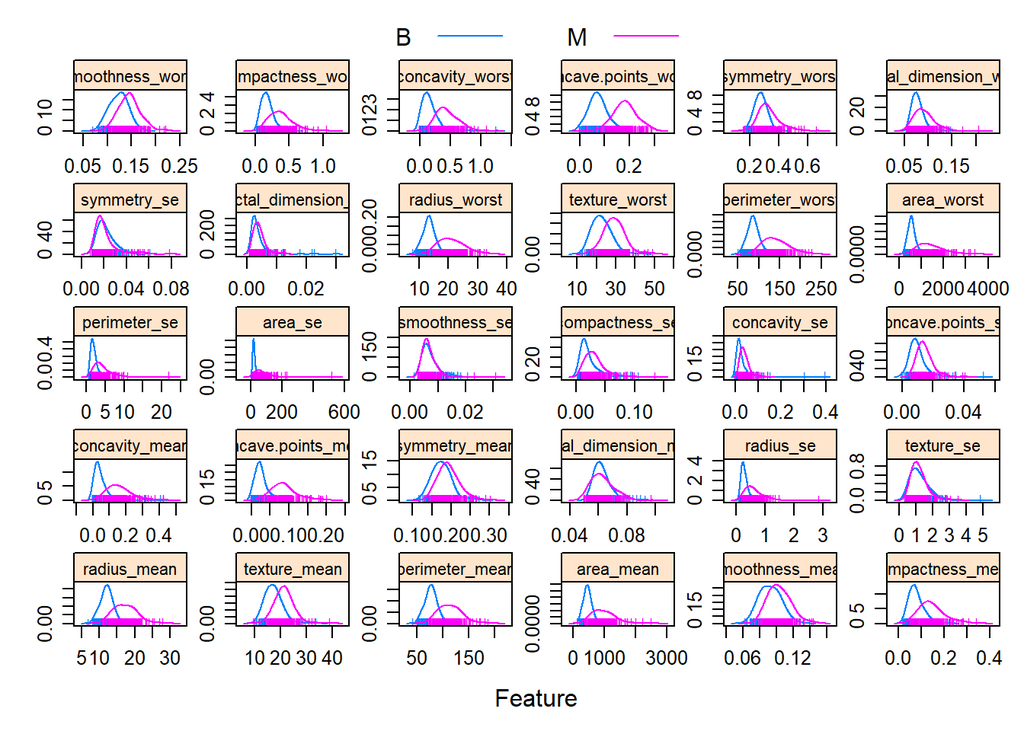

```r
featurePlot(x = diagnosis_data_train[, 2:31],
            y = diagnosis_data_train$diagnosis,
            plot = "density",
            strip=strip.custom(par.strip.text=list(cex=.7)),
            scales = list(x = list(relation="free"),
                          y = list(relation="free")), layout = c(6, 5), adjust = 1.5, pch = "|", auto.key=list(columns=2))
```

- Looking at this output we can see that the following features show higher density dirvergence w.r.t. the 2 target classes:
  - “compactness_worst”
  - “concavity_worst”
  - “concave.points_worst”
  - “radius_worst”
  - “texture_worst”
  - “perimeter_worst”
  - “area_worst”
  - “concavity_mean”
  - “concave.points_mean”
  - “radius_mean”
  - “texture_mean”
  - “perimeter_mean”
  - “area_mean”
  - “compactness_mean”

#### Try a recursive feature elimination check - Feature Selection Method 1

We tried multiple methods to decide which variables to use for feature importance. First one is recursive feature elimination technique as below.

```r
set.seed(100)
options(warn=-1)

subsets <- c(1:5, 15, 20, 25, 31)

ctrl <- rfeControl(functions = rfFuncs,
                   method = "repeatedcv",
                   repeats = 5,
                   verbose = FALSE)

lmProfile <- rfe(x=diagnosis_data_train[, 2:31], y=diagnosis_data_train$diagnosis,
                 sizes = subsets,
                 rfeControl = ctrl)

lmProfile
```

```
##
## Recursive feature selection
##
## Outer resampling method: Cross-Validated (10 fold, repeated 5 times)
##
## Resampling performance over subset size:
##
##  Variables Accuracy  Kappa AccuracySD KappaSD Selected
##          1   0.8657 0.7236    0.04637 0.09417
##          2   0.8991 0.7915    0.04208 0.08706
##          3   0.9103 0.8149    0.03806 0.07821
##          4   0.9253 0.8462    0.03676 0.07571
##          5   0.9426 0.8818    0.03656 0.07480
##         15   0.9545 0.9063    0.02566 0.05263
##         20   0.9563 0.9100    0.02465 0.05074
##         25   0.9573 0.9120    0.02582 0.05318        *
##         30   0.9569 0.9112    0.02605 0.05339
##
## The top 5 variables (out of 25):
##    perimeter_worst, area_worst, radius_worst, concave.points_worst, texture_worst
```

- Key Output: The top 5 variables (out of 25): perimeter_worst, area_worst, radius_worst, concave.points_worst, texture_worst
- These 5 were also identified in the Feature variables distribution check. It is possible that other suitable variables were left out due to strong correlations.

## 4. Data Modeling

- Ethical Framework Questions:
  - Does your use case require a more interpretable algorithm? Accuracy is more impotant than interpretability for this study.
  - Should you be optimizing for a different outcome than accuracy to make your outcomes fairer? Since there is no demographic data, fairness would be hard to determine.
  - Is it possible that a malicious actor has compromised training data and created misleading results? No. The data is from a reputable source.

## 4. A) Data Modeling - Random Forest

#### This gives us a model that is resistant to overfitting.

```r
diag_rf_model <- randomForest(factor(diagnosis) ~ radius_mean + texture_mean + perimeter_mean +
                            smoothness_mean + compactness_mean + concavity_mean + concave.points_mean +
                            symmetry_mean + fractal_dimension_mean +
                            radius_se + texture_se + perimeter_se +
                            smoothness_se + compactness_se + concavity_se + concave.points_se +
                            symmetry_se + fractal_dimension_se +
                            radius_worst + texture_worst + perimeter_worst +
                            smoothness_worst + compactness_worst + concavity_worst + concave.points_worst +
                            symmetry_worst + fractal_dimension_worst,
                         data = diagnosis_data_train)
diag_rf_model
```

```
##
## Call:
##  randomForest(formula = factor(diagnosis) ~ radius_mean + texture_mean +      perimeter_mean + smoothness_mean + compactness_mean + concavity_mean +      concave.points_mean + symmetry_mean + fractal_dimension_mean +      radius_se + texture_se + perimeter_se + smoothness_se + compactness_se +   …
##                Type of random forest: classification
##                      Number of trees: 500
## No. of variables tried at each split: 5
##
##         OOB estimate of  error rate: 4.69%
## Confusion matrix:
##     B   M class.error
## B 239  10  0.04016064
## M  10 167  0.05649718
```

## 5. A) Data Evaluation - Random Forest

#### Test the Random Forest Model

```r
pre_rf <- predict(diag_rf_model, diagnosis_data_test[,-c(1,1)])
cm_rf <- confusionMatrix(pre_rf, diagnosis_data_test$diagnosis)
cm_rf
```

```
## Confusion Matrix and Statistics
##
##           Reference
## Prediction   B   M
##          B 105   0
##          M   3  35
##
##                Accuracy : 0.979
##                  95% CI : (0.9399, 0.9957)
##     No Information Rate : 0.7552
##     P-Value [Acc > NIR] : 6.397e-14
##
##                   Kappa : 0.9449
##
##  Mcnemar's Test P-Value : 0.2482
##
##             Sensitivity : 0.9722
##             Specificity : 1.0000
##          Pos Pred Value : 1.0000
##          Neg Pred Value : 0.9211
##              Prevalence : 0.7552
##          Detection Rate : 0.7343
##    Detection Prevalence : 0.7343
##       Balanced Accuracy : 0.9861
##
##        'Positive' Class : B
##
```

#### Feature Engineering Continued - Feature Selection Method 2

#### Examine the Random Forest Model for feature importance

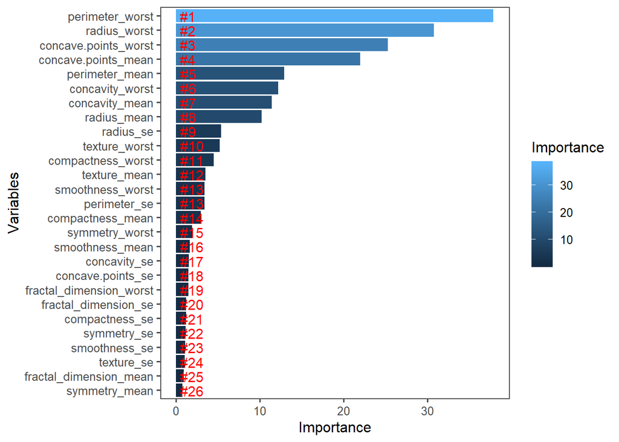

```r
# Get importance
importance    <- importance(diag_rf_model)
varImportance <- data.frame(Variables = row.names(importance),
                            Importance = round(importance[ ,'MeanDecreaseGini'],2))

# Create a rank variable based on importance
rankImportance <- varImportance %>%
  mutate(Rank = paste0('#',dense_rank(desc(Importance))))

# Use ggplot2 to visualize the relative importance of variables
ggplot(rankImportance, aes(x = reorder(Variables, Importance),  y = Importance, fill = Importance)) +
    geom_bar(stat='identity') +
    geom_text(aes(x = Variables, y = 0.5, label = Rank), hjust=0, vjust=0.55, size = 4, colour = 'red') +
    labs(x = 'Variables') + coord_flip() +  theme_few()
```

## 4. B) Data Modeling - Logistic Regression

```r
library('ranger')
dim(breastcancer_data)
```

```
## [1] 569  33
```

```r
# head(breastcancer_data,6)
# summary(breastcancer_data)
names(breastcancer_data)
```

```
##  [1] "id"                      "diagnosis"
##  [3] "radius_mean"             "texture_mean"
##  [5] "perimeter_mean"          "area_mean"
##  [7] "smoothness_mean"         "compactness_mean"
##  [9] "concavity_mean"          "concave.points_mean"
## [11] "symmetry_mean"           "fractal_dimension_mean"
## [13] "radius_se"               "texture_se"
## [15] "perimeter_se"            "area_se"
## [17] "smoothness_se"           "compactness_se"
## [19] "concavity_se"            "concave.points_se"
## [21] "symmetry_se"             "fractal_dimension_se"
## [23] "radius_worst"            "texture_worst"
## [25] "perimeter_worst"         "area_worst"
## [27] "smoothness_worst"        "compactness_worst"
## [29] "concavity_worst"         "concave.points_worst"
## [31] "symmetry_worst"          "fractal_dimension_worst"
## [33] "X"
```

```r
# summarize the class distribution
percentage <- prop.table(table(breastcancer_data$diagnosis)) * 100
cbind(freq=table(breastcancer_data$diagnosis), percentage=percentage)
```

```
##   freq percentage
## B  357   62.74165
## M  212   37.25835
```

```r
#remove id and x
target <- ifelse(breastcancer_data$diagnosis=="B", 1, 0)
#head(target)
model_1 = select (breastcancer_data,-c(X,id,diagnosis))
nobs <- nrow(model_1)
nobs
```

```
## [1] 569
```

```r
# head(model_1)
model_2=scale(model_1)
model_3<-data.frame(cbind(model_2,target))
# summary(model_3)

#model start
library(caTools)
set.seed(123)
split = sample.split(model_3$target, SplitRatio = 0.75)
train_data = subset(model_3, split == TRUE)
test_data = subset(model_3, split == FALSE)

dim(train_data)
```

```
## [1] 427  31
```

```r
# Logistic_Model <- glm(target ~ perimeter_mean +
#                         + smoothness_mean + compactness_mean + concavity_mean + concave.points_mean +
#                         symmetry_mean ,data=train_data, family = binomial)
Logistic_Model <- glm(target ~ perimeter_worst + concave.points_worst + radius_worst + concave.points_mean + concavity_mean,
                      data=train_data, family = binomial)

summary(Logistic_Model)
```

```
##
## Call:
## glm(formula = target ~ perimeter_worst + concave.points_worst +
##     radius_worst + concave.points_mean + concavity_mean, family = binomial,
##     data = train_data)
##
## Deviance Residuals:
##     Min       1Q   Median       3Q      Max
## -3.3039  -0.0167   0.0306   0.1339   1.7468
##
## Coefficients:
##                      Estimate Std. Error z value Pr(>|z|)
## (Intercept)            0.8400     0.2837   2.961 0.003062 **
## perimeter_worst        3.8812     3.0649   1.266 0.205398
## concave.points_worst  -2.4012     0.7159  -3.354 0.000796 ***
## radius_worst          -8.1366     3.0367  -2.679 0.007375 **
## concave.points_mean   -0.2579     0.9038  -0.285 0.775328
## concavity_mean        -0.6809     0.5014  -1.358 0.174423
## ---
## Signif. codes:  0 '***' 0.001 '**' 0.01 '*' 0.05 '.' 0.1 ' ' 1
##
## (Dispersion parameter for binomial family taken to be 1)
##
##     Null deviance: 563.81  on 426  degrees of freedom
## Residual deviance: 109.50  on 421  degrees of freedom
## AIC: 121.5
##
## Number of Fisher Scoring iterations: 8
```